# **The mobilization of young voters:** Evidence from a field experiment

BB Political Behavior Workshop 2024

Frederik  
Thieme

frederik.thieme@hu-berlin.de

Humboldt-Universität zu Berlin

Heike  
Klüver

Humboldt-Universität zu Berlin

September 30, 2024

# Motivation

- perception of *Gen Z* as very `politicized`– but not always the way we expect
- (party) mobilization of young voters as an `ongoing challenge`

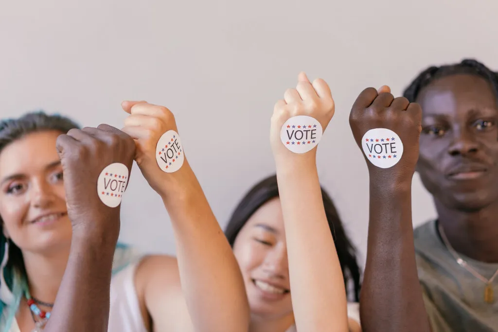

[figure not shown]

# Overview

- ❓ `Question`: Can parties mobilize young people by sending letters to first-time voters?
- 💡 `Expectation`: Positive effect because letters cut through the noise of other omnipresent forms of communication
- ️⚙️ `Data & Method`:
  - field experiment with a German parliamentary party
  - randomized distribution of 37,000 letters
- 📊 `Results`:
  - no effect on turnout or vote share on the aggregate level
  - findings supported by a post-election survey

# Literature & Expectations

- experimental GOTV literature from US finds campaigns to be impactful, but effect sizes vary by target audience *(Gerber & Green, 2019)*
- younger cohorts might be less responsive to traditional mail *(Kalla & Broockman, 2018)*, but tailored messages can be persuasive *(Malhotra et al., 2011)*

Expectation:

- `Positive effect` on turnout as well as party vote share
- tailored, direct letter might *“cut through the noise”*

# Design ⚙️

- `field experiment` with a German parliamentary party
- conducted in one federal state before the `2024 European elections`
- `treatment`
  - 37,000 letters to first-voters (140,000)
  - `randomized distribution` by ZIP-code, blocked by state district
  - `content`: election info, what’s at stake, mail-vote how-to
- `post-election survey` with 1,400 respondents

# Estimation 📊

- `aggregate` analysis of election results:
  - `geospatial match` of ZIP-codes with election districts
  - hypothesis test by `randomization inference`
- `individual-level` survey analysis:
  - OLS with heteroscedasticity robust standard errors

# Aggregate Results

- neither effect on turnout nor party vote share in treated election districts
- `no impact` on overall election outcomes

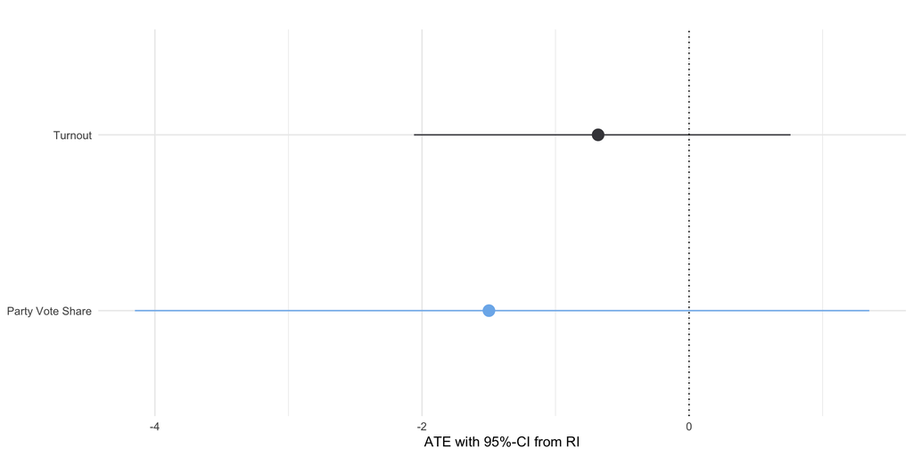

# Survey results

- no effect on turnout or party choice among `surveyed first voters` either

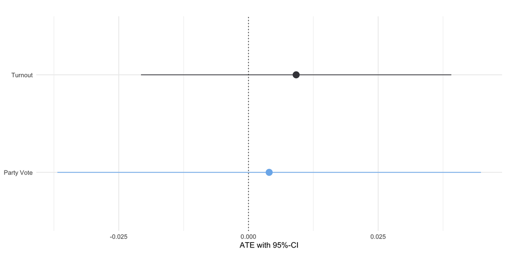

# Mechanisms

- similarly, no evidence that the treatment impacted any of the proposed mechanisms

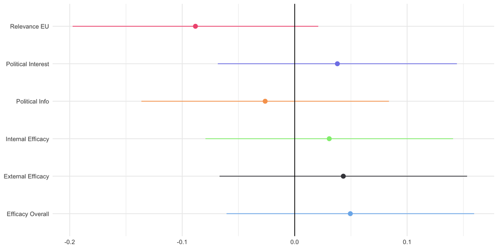

# Caveat: Low recall

- only `37% of treated respondents remember` receiving a letter
- *robustness*: limiting analysis to respondents who recall does not alter findings

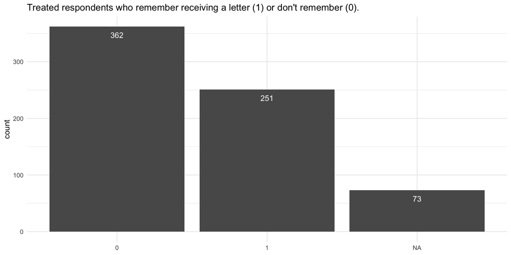

# Conclusion

- `no effect` of direct-letter campaigns to first voters for the 2024 EP election
- campaign costs `better invested elsewhere`
- changing (communication) habits require a repeated `re-evaluation of GOTV measures`

# Post-credit scene 🎥

- using parametric estimation, our experiment would have produced `significant effects across the board`
- `randomization inference` rendered them likely to be “random” – stay alert ⚠️

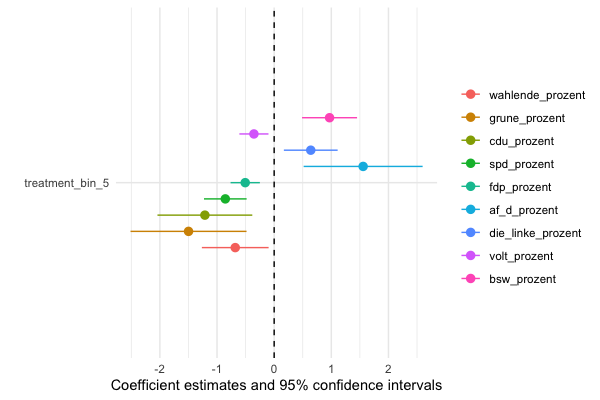

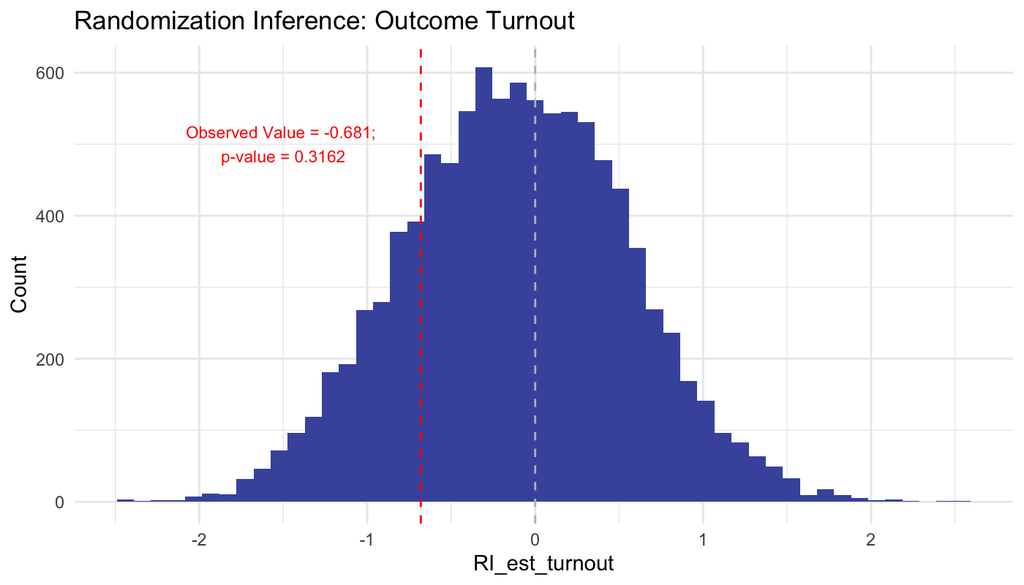

# Thank you for your attention.

Questions or feedback? Hit me up:

- 🌐 [frederikthieme.net](https://frederikthieme.net/)
- 📥 frederik.thieme@hu-berlin.de
- 🟦 frederikthieme.bsky.social
- 🐦 frederik_thieme